# Forecasting kNDVI using Ridge Regression and TimeGPT

Author

Gloria Carrascal

Published

August 3, 2025

# 1 Introduction

In ecosystem monitoring, the study of vegetation dynamics reflects the health and resilience of the place. This report presents a forecasting analysis of the Kernel Normalized Difference Vegetation Index (kNDVI) using two modeling approaches: a baseline Ridge Regression model and the TimeGPT model. The work includes exploratory data analysis, forecasting, and performance evaluation using MAE. Analyzing these dynamics can reveal the impacts of environmental changes like climate change, human activities, and natural disturbances, informing conservation efforts and sustainable management practices.

# 2 Data and Methods

This section describes the dataset used in the study, the preprocessing steps applied, and the forecasting methods implemented. It begins by introducing the kNDVI dataset and its structure, followed by a description of the forecasting models employed to generate predictions and evaluate their performance.

## 2.1 Dataset Description

Table 1: Datasets available to develop the project, summary of the basics shapes and NaN counts.

| Dataset | Unique Ids | Timesteps | NaNs |
| --- | --- | --- | --- |
| Train | 214,751 | 1004 | 0 |
| Validation | 71,755 | 1004 | 0 |

## 2.2 Models

### 2.2.1 Ridge Regression

This method consists of estimating the coefficients of multiple-regression models. It works especially under scenarios where independent variables have a high correlation. The model minimizes the objective function in Equation 1 , but with a twist: it includes **L2 regularization**. This means it not only tries to reduce the error between the predicted and actual values, but it also adds a penalty if the model’s coefficients become too large. Also known as Ridge Regression or Tikhonow regularization (Wikipedia 2025; Developers, n.d.).

$$||y -Xw||^2_2 + alpha *||w||^2_2
\tag{1}$$

In the context of the kNDVI challenge, the ridge regressor model is applied with an univariate time series forecasting approach. Only the target variable, the kNDVI and its time column. However, the ridge regressor doesn’t natively understand time or seasonality (Wikipedia 2025), it was created with a single month lag as an exogenous variable to predict the next 92 timesteps.

### 2.2.2 Nixtla TimeGPT

**TimeGPT** is a production-ready generative pre-trained transformer model specifically designed for time series forecasting. The Figure 1 describes the fine-tuning process architecture from TimeGPT to create the forecast (Liao et al. 2025). In this project, the few-shot learning framework is used. Few-shot learning consists of training an AI model on a very small number of samples (IBM, n.d.). In this case, with TimeGPT, a fine-tuning process is employed to adapt the model to the specific forecast task. Additionally, exogenous variables were given to generate the 92 predictions, `['month', 'quarter', 'year', 'dayofyear']`.

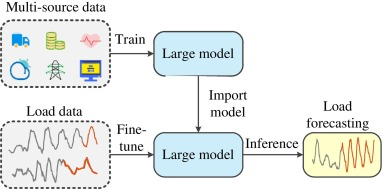

Figure 1: Architecture of the model and fine tuning process involved in TimeGPT to forecast a time series (Liao et al. 2025).

The fine-tuning process is carried out using the full historical load data (see Figure 1). This data is used to update the weights of all layers in the model. The model processes all past values using *self-attention* and builds a latent representation of the full historical context, including trends and seasonal behavior. As the horizon of predictions was long with few years of context the generalizations were poor, the time series variability was trackless.

# 3 Results and Discussion

In this this section we explore the analysis of the two approaches under a spatial validation setting. The first method is based on a simple ridge regression model, while the second uses TimeGPT, a transformer-based model designed to handle long-range temporal dependencies. Both approaches aim to predict the kNDVI signal over a 92-step horizon, but they work in fundamentally different ways.

## 3.1 Model Performance

Model performance was evaluated over a validation period from 2020-02-21 to 2022-02-10, covering 92 time steps at 8-day intervals. The Table 2 summarizes the average MAE, RMSE, and MSE for Ridge Regression and multiple TimeGPT configurations:

The Table 2 shows that,the ridge regression model adopts a straightforward approach. Each pixel is treated independently, and the model uses only one lagged value. This method does not require any spatial beyond the context of each time series and its lagged value. Due to this simplicity, Ridge Regression naturally fits a spatial cross-validation setting: each point can be trained and evaluated independently without any dependency on neighboring points. While this approach is computationally simple and somewhat robust, it lacks the capacity to capture more complex temporal patterns such as seasonality or long-term dependencies.

One of the main goals when modeling spatio-temporal data is to evaluate whether a model can generalize to unseen spatial locations. This ability, often referred to as spatial generalization, is only meaningful if the setup strictly separates training and validation points in space (Goodge et al. 2025). If validation data is mixed model may learn patterns from locations that are supposed to be held out, resulting in overly optimistic evaluation metrics. As a result, some validation points had to be included in the training phase which means the “context data” for TimeGPT model, and a strict test of spatial generalization could not be achieved. TimeGPT expects a history of values for each spatial point, organized under unique identifiers. During forecasting, it predicts future values conditioned on this historical context. However, in this project, the validation set contained entirely different spatial points not present in the training set. Since TimeGPT cannot forecast future values without past observations for each point, we had to include the historical part of the validation series as part of the input. This means the model had access to validation locations during inference, making it impossible to evaluate pure spatial generalization in this setup.

To evaluate the model performance of the Ridge Regressor and TimeGPT forecast, the validation dataset was used. The prediction period corresponds from 2020-02-21 to 2022-02-10, a total of 92 time steps with a frequency of 8 days. The average evaluation metrics of Ridge Regressor and TimeGPT are shown in Table 2.

Table 2: Forecast metrics for Ridge Regressor and TimeGPT models during the prediction of 220,000 time series

| Model | MAE | RMSE | MSE |
| --- | --- | --- | --- |
| Ridge Regressor | 0.1031 | 0.1048 | 0.1031 |
| TimeGPT not fine-tuning (exog) | 0.0430 | 0.0974 | 0.0095 |
| TimeGPT with fine-tuning (exog) | 0.0242 | 0.1665 | 0.0277 |
| TimeGPT not fine-tuning not exog | 0.0620 | 0.1391 | 0.0193 |
| TimeGPT with fine-tuning not exog | 0.0249 | 0.1002 | 0.0100 |
| TimeGPT Half context with fine-tuning (exog) | 0.1618 | 0.2480 | 0.0615 |
| TimeGPT Half context not fine-tuning (exog) | 0.1571 | 0.2427 | 0.0589 |
| TimeGPT Half context no exog, not fine-tuning | 0.1521 | 0.2441 | 0.0596 |
| TimeGPT Half context no exog, fine-tuning | 0.1609 | 0.2465 | 0.0608 |

From a practical standpoint, Ridge Regression offers simplicity and interpretability. It is a strong baseline, especially in scenarios where computational efficiency or explainability is prioritized. TimeGPT, in contrast, demonstrates superior performance when full historical context is available and when the goal is to capture complex temporal dependencies. The trade-off lies in model complexity and the increased attention needed to avoid data leakage.

As shown in Table 2, models like the Ridge Regressor serves as a basic benchmark with moderate error metrics. Notably, TimeGPT outperforms it even without fine-tuning, highlighting its capacity to model richer temporal structures. When fine-tuned—adjusting its transformer layers to minimize the mean squared error—TimeGPT’s performance improves substantially. As a result, TimeGPT with fine-tuning achieves the lowest MAE, establishing it as a highly effective model for vegetation forecasting. Experiments using only half of the available historical context shows an evident drop in performance (See Table 2). This confirms that the model strongly depends on having long historical sequences available per spatial point for time series such the kNDVI signal, which are characterized by high temporal variability, irregular sampling, and missing or interpolated observations. The inclusion of exogenous variables helps in some cases, but the key driver of performance remains the length of the input history. These results suggest that TimeGPT is best suited for dense temporal coverage, and may not generalize well to sparse or truncated histories. This has implications for applying transformer models in environmental forecasting, where data availability can vary across space and time.

## 3.2 Forecast Shape Analysis

Beyond numerical error metrics, evaluating the shape and structure of forecasted time series is essential to understanding how well models capture the dynamics and patterns of the target variable. Visual inspection enables the assessment f qualitative aspects; such as trends, fluctuations, and seasonal behaviors which are not fully reflected by aggregate error values. Starting with Ridge Regression, Figure 2 displays kNDVI forecasts for four spatial points (pixels). While the model yields moderately low error metrics (Table 2), this figure highlights a critical limitation: the predicted time series often fail to replicate the actual signal’s temporal structure. Instead, the forecasts converge to flat or increased line pattenr which are disconnected from the observed kNDVI dynamics. This illustrates how models like Ridge Regression may produce deceptively “good” average errors while missing critical variations in the signal.

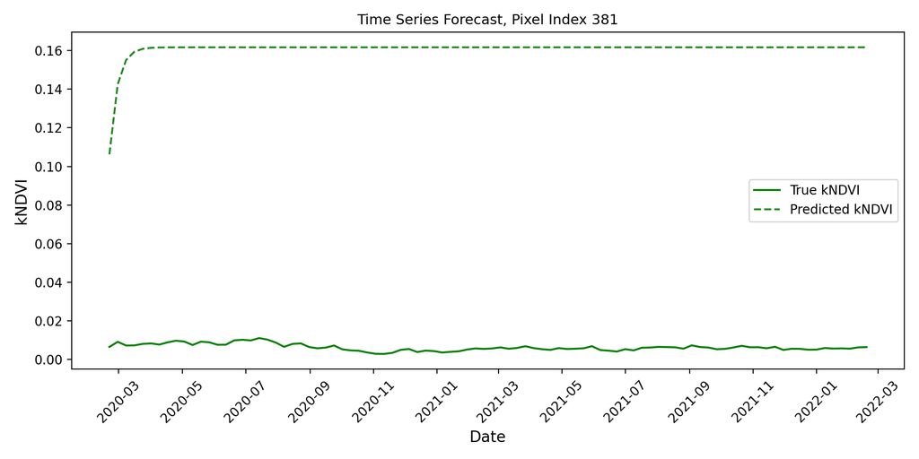

Pixel 381.

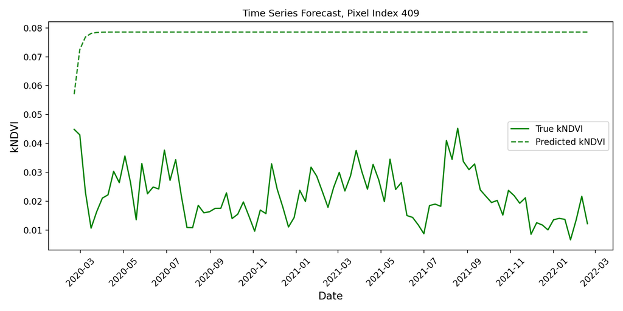

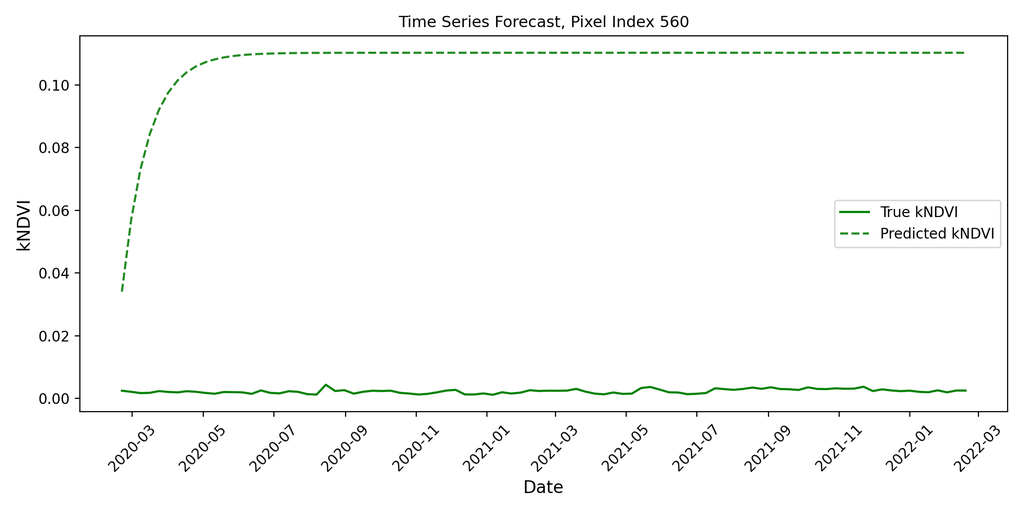

Pixel 560.

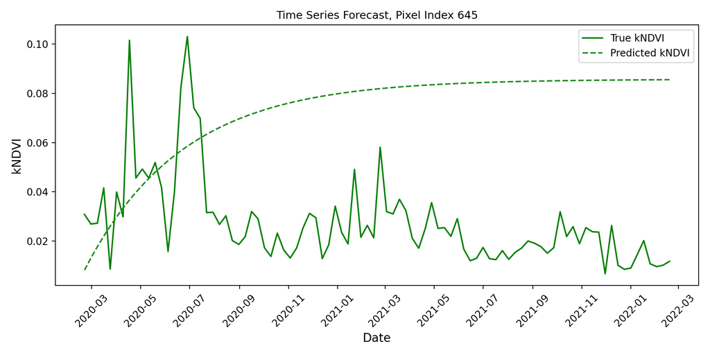

Pixel 645.

In contrast to Ridge Regression (see, Figure 2), Figure 3 presents TimeGPT forecasts under a constrained configuration: short historical context, no exogenous variables, and no fine-tuning. Despite the architectural complexity of TimeGPT, this setup limits its capacity to extract meaningful temporal patterns. As shown, the model produces flat trending predictions that are detached from the actual kNDVI signal. However, while Ridge achieves better error metrics (MAE = 0.1031), it does so by over-smoothing the forecast into a constant or increasing trend. TimeGPT, on the other hand, achieves higher MAE (0.1521) in this limited configuration, revealing its dependency on rich historical context and model adaptation on long horizont predicitons, for effective performance. In the absence of sufficient temporal depth or contextual information, even powerful sequence models like TimeGPT revert to weak baselines, and may perform worse than simpler linear methods.

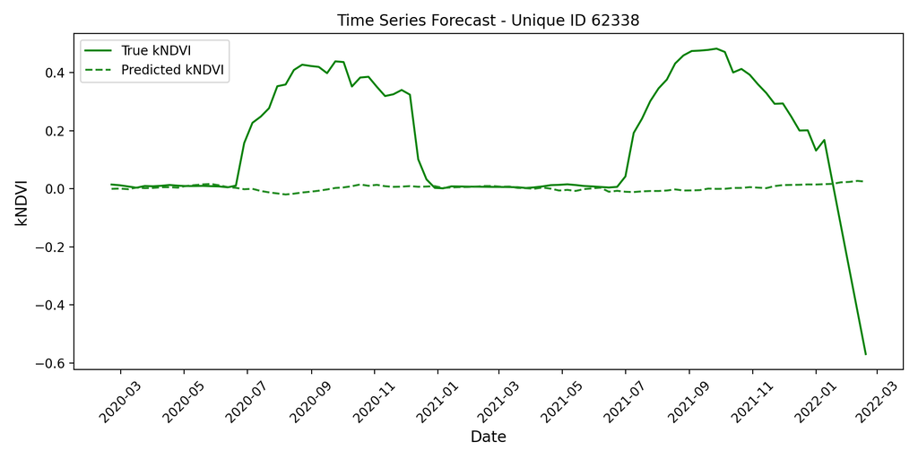

Unique ID 62338.

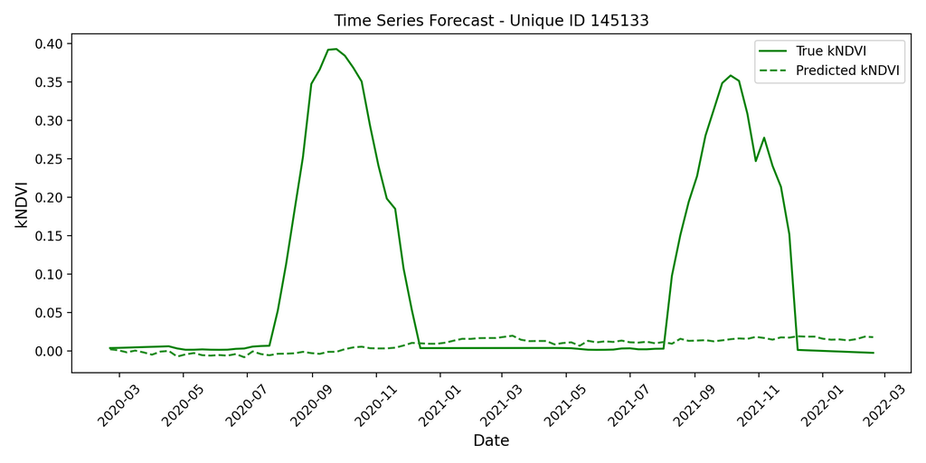

Unique ID 145133.

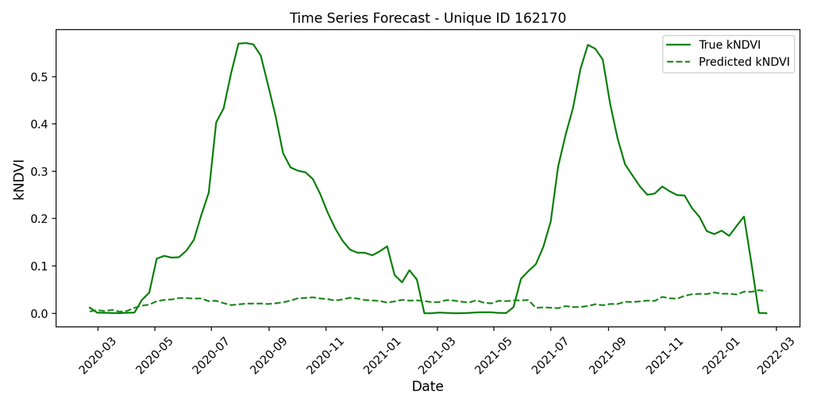

Unique ID 162170.

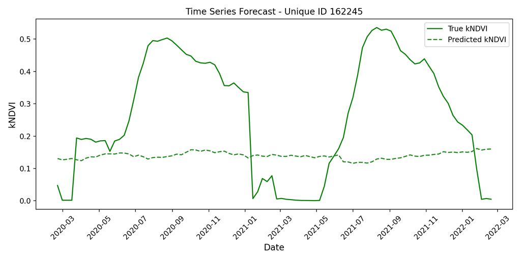

Unique ID 162245.

Figure 3: TimeGPT predictions (dashed green line) compared to actual kNDVI values (solid green line) for selected spatial points. In this configuration, short context, not exogenous variables, and not fine-tuning were applied.

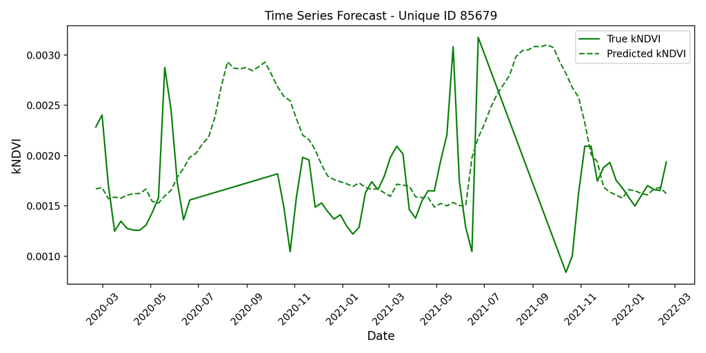

Unique ID 85679.

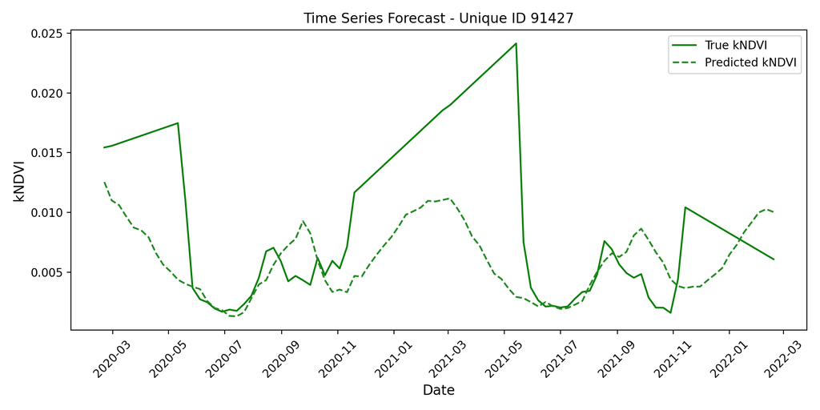

Unique ID 91427.

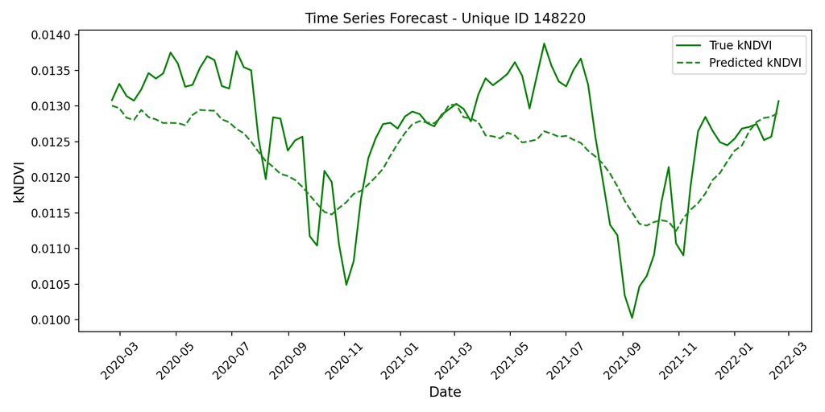

Unique ID 148220.

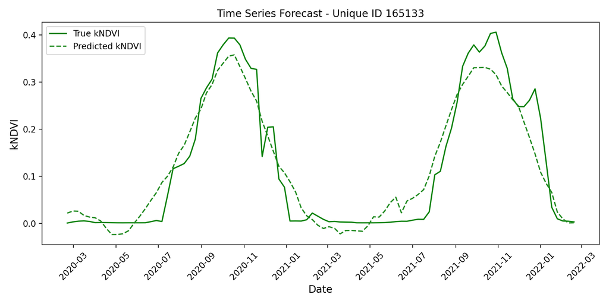

Unique ID 165133.

Figure 4: TimeGPT predictions (dashed green line) compared to actual kNDVI values (solid green line) for selected spatial points. This configuration includes all the context, exogenous variables, and fine-tuning.

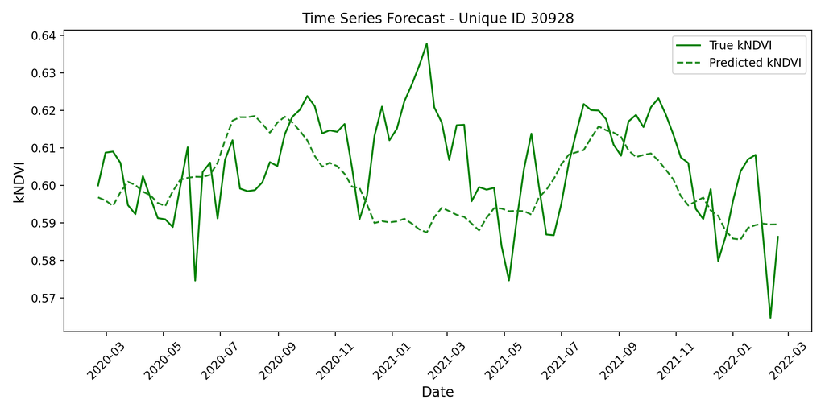

Unique ID 30928.

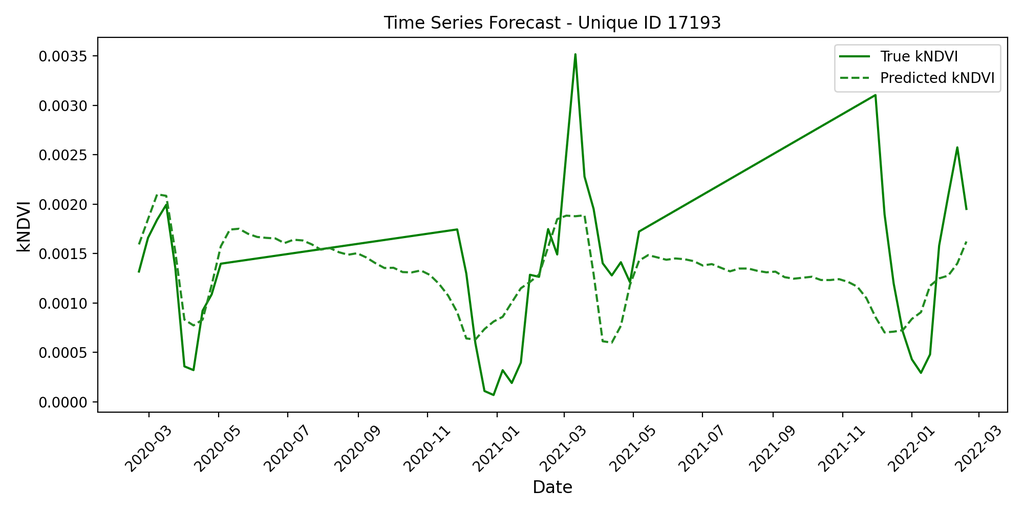

Unique ID 17193.

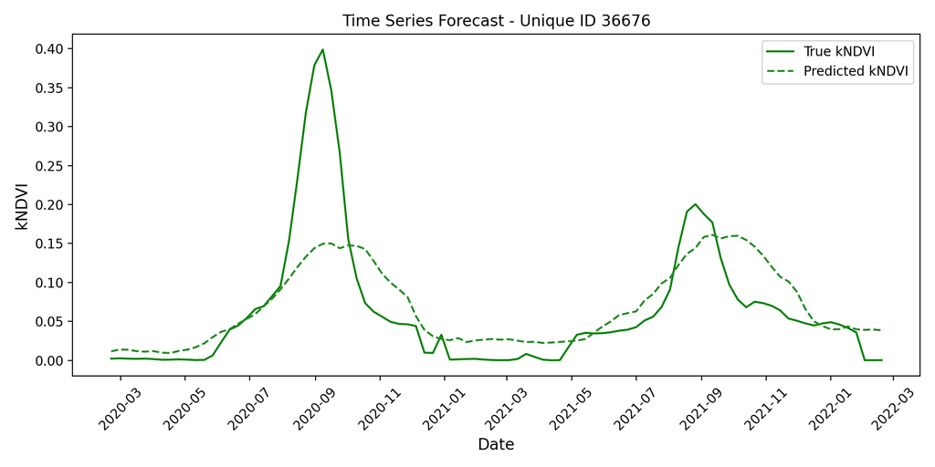

Unique ID 36676.

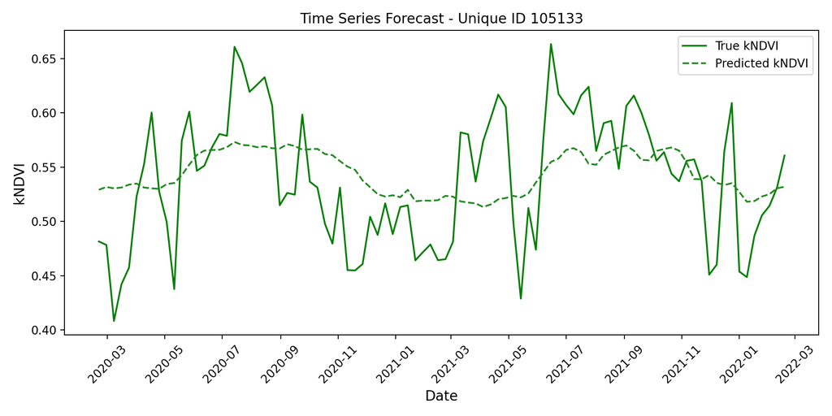

Unique ID 105133.

Figure 5: TimeGPT predictions (dashed green line) versus actual kNDVI values (solid green line) for four selected spatial points. Full historical, exogenous variables, and no fine-tuning was applied.

What we take from this exercise is that, although TimeGPT is a pre trained model originally developed for time series forecasting, particularly in the financial domain (Nixtla 2023); applying it to kNDVI prediction posed a nontrivial, yet surmountable, challenge. Due to the scale of the dataset, which includes approximately 220,000 unique time series, forecasts had to be executed in batches of 20,000 unique IDs, resulting in eleven separate API calls. In contrast, the Ridge Regressor handled the full dataset in a single execution, requiring significantly less computational effort and no batching. However, the trade-off is evident: while TimeGPT is more computationally demanding, it delivers substantially better results in capturing the temporal dynamics and variability of the kNDVI signal, especially when is fine tuned. This underscores the value of using transformer based models for environmental forecasting tasks, provided that sufficient historical data and resources for adaptation are available.

## 3.3 Technical Challenges

To predict the kNDVI signals, several preprocessing and computationals tricks had to be addressed. The first critial step during before the forecast was the transformation of the input data into TimeGPT’s required format. This data structure may be flexible for general time series tasks, but lacks of native support for geospatial structures such datacubes. In this project, each cube had to be uniquely identified by joining latitude and longitude coordinates into a string-based unique ID, and grouped into batches for each forecast. The second step during execution, was to send the API the data. The API displays a progressive computation pattern (e.g., from 0% to 100% across batches), reflecting the non trivial effort required to handle long sequences. Internally, the model issues a warning when the forecast horizon exceeds its pretrained limits:

```
WARNING - The specified horizon "h" exceeds the model horizon, this may lead to less accurate forecasts.
Please consider using a smaller horizon.
```

This suggests that forecasting long sequences may stretch the model beyond its optimal capacity, which should be taken into account in production scenarios. Additionally, the model uses inferred frequencies and requires exogenous variables such as month, quarter, year, and dayofyear, but does not provide feature importance, limiting interpretability. Being able to assess which features matter most would allow users to reduce complexity by selecting only relevant exogenous inputs.

# 4 Conclusions

This study demonstrates that TimeGPT can effectively forecast the kNDVI signal when provided with sufficient historical context. Despite being originally developed for financial time series applications (Nixtla 2023), the model exhibits strong adaptability to environmental data, achieving reliable long-horizon forecasts of up to 92 time steps. When fine tuned and enriched with exogenous variables, TimeGPT outperforms a Ridge Regression baseline across multiple metrics, while also more accurately capturing the shape, amplitude, and dynamics of the kNDVI signal.

From a modeling perspective, Ridge Regression offers simplicity, interpretability, and computational efficiency, making it a practical benchmark for large-scale applications. However, its inability to model complex temporal patterns limits its usefulness for detailed environmental forecasting. In contrast, TimeGPT excels when long historical sequences are available. Yet, the model’s effectiveness is highly contingent on full context, and fine tuning. Without these elements, even a powerful transformer architecture may underperform and revert to generic or smoothed predictions.

The analysis also underscores that numerical error metrics alone are insufficient to evaluate model quality. Forecast shape analysis revealed that while Ridge Regression and non fine tuned TimeGPT may yield moderate error values, they fail to capture relevants signal characteristics such as seasonal fluctuations, abrupt changes, or localized anomalies. In contrast, the fine tuned version of TimeGPT accurately reconstructs these dynamics, demonstrating its potential for real world vegetation monitoring tasks.

This study also presents important technical challenges, forecasting with TimeGPT at scale required transforming gridded data into a flat format using string based unique identifiers and executing forecasts in batches due to API limits. This workaround does not scale well and highlights the need for forecasting APIs that natively support geospatial data formats (e.g., H3, S2, or lat/lon pair indexing). Furthermore, the model’s reliance on inferred frequencies and pre-defined exogenous inputs, without offering feature importance diagnostics, limits transparency and interpretability. While the current TimeGPT framework is designed for univariate time series, future extensions could explore incorporating spatial context or generalization capabilities, enabling forecasts for previously unseen locations based on learned spatial relationships. This would open new possibilities for applying transformer-based models to spatio temporal problems in Earth observation. Finally, TimeGPT shows promising potential for **gap-filling and temporal interpolation** in satellite-derived time series, where missing observations due to cloud cover, sensor issues, or preprocessing errors are common. Once provided with full historical context, the model successfully generalizes the temporal dynamics, making it a valuable tool for Earth observation and remote sensing tasks, provided sufficient computational resources and contextual information are available.

# 5 Acknowledgement

This project was developed as part of the Time Series course in the Earth System Data Science and Remote Sensing Master’s program, within the context of the kNDVI Prediction Challenge. We gratefully acknowledge the support of Nixtla, who provided access to the TimeGPT API for experimentation and scientific exploration.

## References

Developers, Scikit-learn. n.d. “Ridge.” https://scikit-learn.org/stable/modules/generated/sklearn.linear_model.Ridge.html.

Goodge, Adam, Wee Siong Ng, See-Kiong Ng, and Bryan Hooi. 2025. “Spatio-Temporal Foundation Models: Vision, Challenges, and Opportunities.” *arXiV*. https://arxiv.org/html/2501.09045v2#abstract.

IBM. n.d. “What Is Few-Shot Learning?” https://www.ibm.com/think/topics/few-shot-learning.

Liao, Wenlong, Shouxiang Wang, Dechang Yang, Zhe Yang, Jiannong Fang, Christian Rehtanz, and Fernando Porté-Agel. 2025. “TimeGPT in Load Forecasting: A Large Time Series Model Perspective.” *Applied Energy* 379: 124973. https://doi.org/https://doi.org/10.1016/j.apenergy.2024.124973.

Nixtla. 2023. “Introduction - TimeGPT Foundational Model for Time Series Forecasting and Anomaly Detection.” www.nixtla.io/docs/introduction/introduction.

Wikipedia. 2025. “Ridge Regression.” https://en.wikipedia.org/wiki/Ridge_regression.

## Footnotes

[^1]: [kNDVI Prediction Challenge, documentation](https://git.sc.uni-leipzig.de/ss2025std/kndvi-prediction-challenge)